# An analysis of forest clearances

## Load data

Data is accessed from the PARIVESH portal.

```r
# Load required libraries
library(tidyverse)
library(rlang)
library(lubridate)
library(scico)
```

### Pre-2014 data

```r
## read in the data prior to 2014
pre_2014 <- read_csv("Data/forest_clearance/for_clear_before_2014.csv")
# rename columns
pre_2014 <- pre_2014 %>%
  `colnames<-`(str_replace_all(str_to_lower(colnames(.)),
                               " ", "_"))

# get year of applications
pre_2014 <- mutate(pre_2014,
                   year = year(dmy(date_from_ua_to_nodal))) %>%
  filter(year >= 1994)
```

### Post-2014 data

```r
# get the same data for post 2014 period
post_2014 <- list.files("Data/forest_clearance/",
                        pattern = "after_2014",
                        full.names = TRUE) %>%
  str_subset("Renew", negate = T)
post_2014 <- map(post_2014, read_csv)
post_2014 <- map(post_2014, function(x) {
  mutate_at(x, vars("user_id"), as.character)
})
post_2014 <- bind_rows(post_2014)

post_2014 <- post_2014 %>%
  `colnames<-`(str_replace_all(str_to_lower(colnames(.)),
                               " ", "_"))

# get year
post_2014$year <- post_2014$date_from_ua_to_nodal %>% dmy() %>% year
```

### Bind data

```r
# subset
post_2014_clean <- select(post_2014, any_of(colnames(pre_2014)))

# bind
forest_data <- bind_rows(pre_2014, post_2014_clean)

# correct case
forest_data$category <- str_to_lower(forest_data$category)
```

## Basic analyses

### Getting the status of applications

```r
# get broader categories
forest_data <- forest_data %>%
  mutate(status = case_when(
    str_detect(proposal_status,
               regex("(PENDING|RETURNED|SECRETARY|COMPLIANCE|Under examination|Draft)",
                     ignore_case = TRUE)) ~
      "pending",
    str_detect(proposal_status, regex("APPROVED|IN-PRINCIPLE",
                                      ignore_case = TRUE)) ~
      "successful",
    str_detect(proposal_status, regex("REJECTED|REVOKED|WITHDRAWN|CLOSED",
                                      ignore_case = TRUE)) ~
      "unsuccessful",
    T ~ "other"
  ))

# get period
forest_data <- forest_data %>%
  filter(year < 2020) %>%
  mutate(period = case_when(
    year < 2006 ~ "2000 - 2005",
    year >= 2006 & year < 2014 ~ "2006 - 2013",
    year >= 2014 ~ "2014 - 2019",
    T ~ NA_character_
  )) %>%
  drop_na(period)

# relevel factors
forest_data <- forest_data %>%
  mutate(status = forcats::fct_relevel(status,
                                       "successful",
                                       "pending",
                                       "unsuccessful",
                                       "other"))

# remove duplicate user ids
```

### Area applied for over years

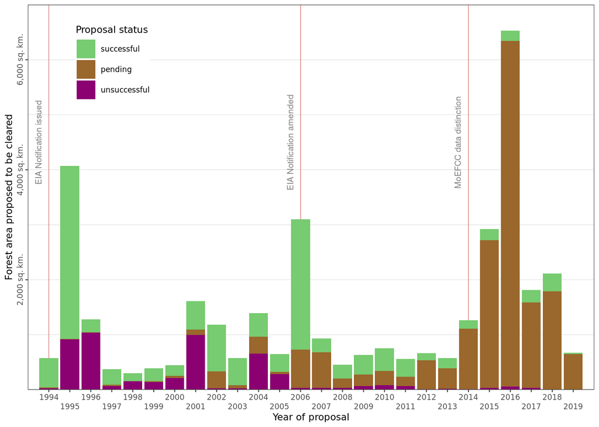

```r
  ggplot() +
  geom_vline(xintercept = c(c(1994, 2006, 2014)),
             col = "indianred", size = 0.2) +
  stat_count(data = forest_data %>%
               filter(!status %in% "other"),
               aes(x = year, fill = status,
                   weight = area_applied * 0.01),
             # width = 0.75,
             geom = "bar",
             position = "stack") +
  annotate("text",
           x = c(1994, 2006, 2014)-c(0.5),
           y = 4500,
           size = 2.5,
           label = c("EIA Notification issued",
                     "EIA Notification amended",
                     "MoEFCC data distinction"),
           col = "grey50",
           angle = 90) +
  scale_x_continuous(guide = guide_axis(n.dodge = 2),
                   label = str_to_title,
                   breaks = 1994:2019)+
  scale_y_continuous(labels = scales::comma_format(suffix = " sq. km."),
                     breaks = seq(2,6,2)*1e3) +
  scale_fill_scico_d(palette = "hawaii",
                     begin = 0, end = 0.7,
                     direction = -1,
                     name = "Proposal status") +
  theme_test(base_family = "TT Arial",
             base_size = 8)+
  theme(legend.position = c(0.15,0.85),
        axis.text.y = element_text(angle = 90,
                                   hjust = 0.5),
        panel.grid.major.y = element_line(size = 0.1,
                                          colour = "grey"),
        panel.grid.minor.y = element_line(size = 0.1,
                                          colour = "grey"))+
  # facet_grid(~period, scales = "free_x") +
  coord_cartesian(xlim = c(1993, 2020),
                  ylim = c(0, 7000),
                  expand = F) +
  labs(x = "Year of proposal",
       y = "Forest area proposed to be cleared")
```

```r
ggsave("Figures/fig_area_by_year.png",
       dpi = 300,
       height = 4, width = 6)
```

## Rule change years and other years

### Prepare data for models

```r
data_rule_change <- forest_data %>%
  group_by(year, period) %>%
  summarise(total_area = sum(area_applied),
            proportion_approved = length(status[status == "successful"])
            / length(status)) %>%
  mutate(event = if_else(year %in% c(1995, 2006),
                         "rule change", "other"))
```

### Area in relation to rule change

```r
# fit a simple linear model for area
# quasipoisson for overdispersion
model_area <- glm(total_area ~ event,
   data = data_rule_change,
   family = "quasipoisson")

# print model summary
summary(model_area)
```

```
##
## Call:
## glm(formula = total_area ~ event, family = "quasipoisson", data = data_rule_change)
##
## Deviance Residuals:
##     Min       1Q   Median       3Q      Max
## -309.63  -199.01  -146.08    47.31  1072.18
##
## Coefficients:
##                  Estimate Std. Error t value Pr(>|t|)
## (Intercept)       11.6931     0.2179   53.66   <2e-16 ***
## eventrule change   1.0972     0.4875    2.25   0.0339 *
## ---
## Signif. codes:  0 '***' 0.001 '**' 0.01 '*' 0.05 '.' 0.1 ' ' 1
##
## (Dispersion parameter for quasipoisson family taken to be 136467.7)
##
##     Null deviance: 2657597  on 25  degrees of freedom
## Residual deviance: 2109080  on 24  degrees of freedom
## AIC: NA
##
## Number of Fisher Scoring iterations: 5
```

```r
# print means and sd
data_area_summary <- group_by(data_rule_change, event) %>%
  mutate(total_area_km = total_area * 0.01) %>%
  summarise_at(vars("total_area_km"), .funs = list(mean_area = mean,
                                                sd_area = sd))

data_area_summary %>%
  knitr::kable()
```

| event | mean_area | sd_area |
| --- | --- | --- |
| other | 1197.466 | 1303.2068 |
| rule change | 3587.178 | 687.2126 |

```r
# print % difference relative to normal years
abs(diff(data_area_summary$mean_area)) / min(data_area_summary$mean_area)
```

```
## [1] 1.99564
```

In years in which EIA rules were changed (1995 and 2006), applications are made to clear 200% more forest land than in other years.

### Area approved in relation to rule change

```r
# summarise the data and print
data_area_approved <-
forest_data %>%
  filter(status == "successful") %>%
  group_by(year) %>%
  summarise(total_area = sum(area_applied)) %>%
  mutate(event = if_else(year %in% c(1995, 2006),
                         "rule change", "other"))
# fit a simple linear model for area approved
# quasipoisson for overdispersion
model_area_approved <- glm(total_area ~ event,
   data = data_area_approved,
   family = "quasipoisson")

# print model summary
summary(model_area_approved)
```

```
##
## Call:
## glm(formula = total_area ~ event, family = "quasipoisson", data = data_area_approved)
##
## Deviance Residuals:
##     Min       1Q   Median       3Q      Max
## -205.34   -67.68   -33.48    53.50   256.72
##
## Coefficients:
##                  Estimate Std. Error t value Pr(>|t|)
## (Intercept)       10.3169     0.1171   88.13  < 2e-16 ***
## eventrule change   2.2122     0.1781   12.42 6.07e-12 ***
## ---
## Signif. codes:  0 '***' 0.001 '**' 0.01 '*' 0.05 '.' 0.1 ' ' 1
##
## (Dispersion parameter for quasipoisson family taken to be 9946.432)
##
##     Null deviance: 1425074  on 25  degrees of freedom
## Residual deviance:  223003  on 24  degrees of freedom
## AIC: NA
##
## Number of Fisher Scoring iterations: 4
```

```r
# print table
data_area_approved_summary <- data_area_approved %>%
  mutate(total_area_km = total_area * 0.01) %>%
  group_by(event) %>%
  summarise_at(vars("total_area_km"), .funs = list(mean_area = mean,
                                                sd_area = sd))

data_area_approved_summary %>%
  knitr::kable()
```

| event | mean_area | sd_area |
| --- | --- | --- |
| other | 302.4002 | 173.0824 |
| rule change | 2762.6557 | 547.5280 |

In years in which EIA rules were changed (1995 and 2006), 814% more forest land was approved for clearance than in other years.

### Proportion of success in relation to rule change

```r
# add time to present as a linear predictor
data_rule_change <- data_rule_change %>%
  mutate(time_to_present = 2020 - year)

# fit a simple glm with binomial family
model_approval <- glm(proportion_approved ~ event +
                        time_to_present,
                      data = data_rule_change,
                      family = "binomial")
# print summary
summary(model_approval)
```

```
##
## Call:
## glm(formula = proportion_approved ~ event + time_to_present,
##     family = "binomial", data = data_rule_change)
##
## Deviance Residuals:
##      Min        1Q    Median        3Q       Max
## -0.41500  -0.18068  -0.05278   0.21090   0.38848
##
## Coefficients:
##                  Estimate Std. Error z value Pr(>|z|)
## (Intercept)      -0.49830    0.84153  -0.592    0.554
## eventrule change -0.03236    1.72964  -0.019    0.985
## time_to_present   0.08115    0.06037   1.344    0.179
##
## (Dispersion parameter for binomial family taken to be 1)
##
##     Null deviance: 3.4509  on 25  degrees of freedom
## Residual deviance: 1.4007  on 23  degrees of freedom
## AIC: 28.866
##
## Number of Fisher Scoring iterations: 4
```

## Land applied for clearance post 2014

```r
# how much area on average applied for before and after 2014
area_by_2014 <- forest_data %>%
  mutate(period = ifelse(year < 2014, "pre-2014", "post-2014")) %>%
  group_by(year, period) %>%
  summarise(area_applied = sum(area_applied)) %>%
  group_by(period) %>%
  summarise_at(vars(area_applied), list(mean_area_per_year = mean))
# print data
knitr::kable(area_by_2014)
```

| period | mean_area_per_year |
| --- | --- |
| post-2014 | 255279.3 |
| pre-2014 | 102984.0 |

## Estimate forest clearance post 2014

### Proportion of forest area approved pre-2014

Here, we look at the proportion of forest area successfully applied to be cleared. We disregard “pending” applications as their outcome is unknown.

```r
# how much land area was successful as a proportion of decided proposals
prop_area_approved_pre2014 <- forest_data %>%
  filter(year < 2014) %>%
  summarise(prop_area_approved_pre_2014 = sum(area_applied[status == "successful"]) /
              sum(area_applied[status %in% c("successful", "unsuccessful")]))

# total area approved for clearance
total_area_approved_pre2014 <- forest_data %>%
  filter(year < 2014, status == "unsuccessful") %>%
  .$area_applied %>%
  sum(.)

# in sq km
total_area_approved_pre2014 <- total_area_approved_pre2014 * 0.01
```

### Total area potentially approved for clearance post 2014

We apply the approval rate of 70% to pending proposals made after 2014, to get a rough estimate of forest area that will potentially be approved for clearance.

```r
# get the approval rate
approval_rate_pre_2014 <- prop_area_approved_pre2014$prop_area_approved_pre_2014

# what area in sq km may be approved assuming a pre 2014 approval?
# requires a hectares to sq km conversion
area_cleared_post_2014 <- forest_data %>%
  filter(year >= 2014,
         status == "pending") %>%
  summarise(area_potentially_cleared = sum(area_applied) *
              approval_rate_pre_2014 * 0.01)
```

### Projected clearances in relation to pre-2014 clearances

```r
# how much more than pre 2014 approved clearances are the projected
# post 2014 clearances?
area_cleared_post_2014$area_potentially_cleared / total_area_approved_pre2014
```

```
## [1] 2.018461
```